[figure not shown]

# Fundamentos de AI & Machine Learning

## Introdução ao Python

1. Tipos de Dados e Operadores  
   1.1 Operadores Aritméticos;  
   1.2 Variáveis e operadores de atribuição;  
   1.3 Booleanos, operadores de comparação e op. lógicos;  
   1.4 Strings;  
   1.5 Tipo e conversão de tipo;  
   1.6 Listas;  
   1.7 Tuplas;  
   1.8 Set;  
   1.9 Dicionário;  
   1.10 Estruturas de dados compostas;  
   1.11 Exercícios Práticos;
2. Controle de Fluxo  
   2.1 Declarações condicionais;  
   2.2 Expressões booleanas para condições;  
   2.3 Expressões booleanas para condições;  
   2.4 Loops For;  
   2.5 Loops While;  
   2.6 Zip e enumeração;  
   2.7 Compreensão de listas;
3. Funções  
   3.1 Definindo Funções;  
   3.2 Expressões lambda;
4. Scripting  
   4.1 Lidando com erros;
5. Projeto: Explore os dados de bicicletas compartilhadas de Chicago

## Tipos de Dados e Operadores

### Quiz: Operadores Aritméticos

*Minhas contas de energia elétrica nos últimos três meses foram de 23, 32 e 64. Qual é a média da fatura de energia elétrica durante o período de três meses? Escreva uma expressão aritmética para calcular a média destas quantidades e use o comando print() para ver o resultado.*

```python
# Escreva uma expressao que calcule a media de 23, 32 e 64, ou seja, some os tres numeros e divida por 3.0.

print((23 + 32 + 64) / 3.0)
```

```
39.666666666666664
```

*Você vai fazer alguns cálculos para um ladrilhador. Duas partes de um piso precisam de azulejos. Uma parte tem 9 azulejos de largura por 7 azulejos de comprimento, a outra tem 5 azulejos de largura por 7 azulejos de comprimento. Os azulejos vêm em pacotes de 6.*

1. *Quantos azulejos são necessários?*
2. *Você compra 17 pacotes, contendo 6 azulejos em cada. Quantos azulejos vão sobrar?*

```python
# Preencha aqui com uma expressao que calcule quantos azulejos sao necessarios
print(9*7 + 5*7)

# Preencha aqui com uma expressao que calcule quantos azulejos sobrarao
print((17*6)-(9*7 + 5*7))
```

```
98
4
```

### Quiz: Variáveis e operadores de atribuição

*Os comentários neste quiz (as linhas que começam com #) têm instruções para criar e modificar variáveis. Depois de cada comentário, escreva uma linha de código que implemente a instrução.*

*Observe que esse código usa notação científica para definir um número grande. 4.445 e 8 é igual a 4.445* 10 * *8 que é igual a 444500000.0.*

```python
# Volume atual de um reservatório de água (em metros cúbicos)
reservoir_volume = 4.445e8
# Total de água da chuva de uma tempestade(em metros cúbicos)
rainfall = 5e6

# Reduza a variável de água da chuva(rainfall) em 10% para considerar perdas
rainfall *= 0.9

# Adicione a variável rainfall à variaável de vol. atual do reservatório(reservoir_volume)
reservoir_volume += rainfall

# Aumente o volume do reservatório (reservoir_volume) em 5% para considerar águas tempestuosas
# que chegam no reservatório dias apoós a tempestade
reservoir_volume *= 1.05

# Reduza o volume do reservatório (reservoir_volume) em 5% para considerar evaporaçaão
reservoir_volume *= 0.95

# Subtraia 2.5e5 metros cúbicos de reservoir_volume para considerar água
# que é direcionada para regiões áridas.
reservoir_volume -= 2.5e5

# Execute um print do novo valor de reservoir_volume
print(reservoir_volume)
```

```
447627500.0
```

*Como uma alteração de um valor em uma variável afeta outra variável que foi definida em termos dela?*

```python
rabbits = 8
carrots = 4
crs_per_rab = carrots/rabbits

print("rabbits", rabbits)
print("crs_per_rab", crs_per_rab)

rabbits = 12
print("crs_per_rab após alteração de rabbits", crs_per_rab)
```

```
rabbits 8
crs_per_rab 0.5
crs_per_rab após alteração de rabbits 0.5
```

### Quiz: Booleanos, operadores de comparação e op. lógicos

*Esse código calcula a densidade populacional do Rio de Janeiro e de São Francisco. Escreva o código para comparar essas densidades. São Francisco é mais densa do que o Rio de Janeiro? Seu código deve exibir(print) True se for e False caso não seja. Dica: precisamos de apenas uma comparação.*

```python
sf_population, sf_area = 864816, 231.89
rio_population, rio_area = 6453682, 486.5

san_francisco_pop_density = sf_population/sf_area
rio_de_janeiro_pop_density = rio_population/rio_area

# Escreva um código que imprima na tela (print) True se
#  San Francisco for mais densa que Rio e False caso contrário
print(san_francisco_pop_density > rio_de_janeiro_pop_density)
```

```
False
```

### Quiz: Strings

*A linha de código no quiz a seguir causará um SyntaxError, graças à utilização indevida de aspas. Primeiro, faça uma execução de teste para ver a mensagem de erro. Em seguida, resolva o problema para que a citação (de Henry Ford) seja corretamente atribuída à variável ford_quote.*

```python
# TODO: Arrume essa String!
#ford_quote = 'Whether you think you can, or you think you can't--you're right.'
```

```python
ford_quote = 'Whether you think you can, or you think you can\'t--you\'re right.'
```

*Qual será a saída deste código?*

```python
coconut_count = "34"
mango_count = "15"

tropical_fruit_count = coconut_count + mango_count
print(tropical_fruit_count)
```

```
3415
```

*Escreva uma mensagem de log no servidor. Forneceremos exemplos de dados de um usuário, com o tempo de sua visita e o site acessado. Você deve usar as variáveis fornecidas e as técnicas que aprendeu para imprimir uma mensagem de log como esta (com o nome de usuário, URL e marcação de tempo substituídos pelos valores das variáveis apropriadas):*

*Yogesh accessed the site http://petshop.com/pets/reptiles/pythons at 16:20.*

*Use o botão de execução de teste para ver os resultados enquanto você trabalha no código pedaço por pedaço.*

```python
username = "Kinari"
timestamp = "04:50"
url = "http://petshop.com/pets/mammals/cats"

# TODO: imprima(print) uma mensagem de log incorporando as Strings acima.
# A mensagem deve seguir o mesmo formato que:
# "Yogesh accessed the site http://petshop.com/pets/reptiles/pythons at 16:20."
print(username +  " accessed the site " + url + " at " + timestamp + ".")
```

```
Kinari accessed the site http://petshop.com/pets/mammals/cats at 04:50.
```

*Utilize a concatenação de strings e a função len para encontrar o comprimento do nome completo de uma estrela de cinema real. Armazene esse comprimento na variável name_length. Não se esqueça de que existem espaços entre as diferentes partes de um nome!*

```python
given_name = "William"
middle_names = "Bradley"
family_name = "Pitt"

complete_name = given_name + " " + middle_names + " " + family_name

name_length = len(given_name + middle_names + family_name) + 2

# Confirme se o nome tem o número de caracteres permitido na Carteira de Motorista
driving_license_character_limit = 28
print(name_length <= driving_license_character_limit)
```

```
True
```

### Quiz: Tipo e conversão de tipo

*Calcule e exiba o total de vendas da semana a partir dos dados fornecidos. Exiba uma string da forma "This week's total sales: xxx", onde xxx será o total real de todos os números. Você precisará alterar os tipos de dados de entrada a fim de calcular o total.*

```python
mon_sales = "121"
tues_sales = "105"
wed_sales = "110"
thurs_sales = "98"
fri_sales = "95"

#TODO: Imprima(Print) uma String no formato: This week's total sales: xxx
# É provável que você precise escrever algumas linhas de código antes do print.
sales = int(mon_sales) + int(tues_sales) + int(wed_sales) + int(thurs_sales) + int(fri_sales)
print("This week's total sales:",sales)
```

```
This week's total sales: 529
```

### Quiz: Listas

*Use a indexação de lista para determinar quantos dias existem em um mês específico com base na variável month, de tipo inteiro, e armazene esse valor na variável de tipo inteiro num_days. Por exemplo, se month for 8, num_days deve ser definida como 31, já que o oitavo mês, agosto, possui 31 dias. Lembre-se de considerar que a indexação é baseada no zero!*

```python
month = 8
days_in_month = [31,28,31,30,31,30,31,31,30,31,30,31]

# Use a indexação de lista para definir a variável num_days com quantos dias existem em um mês específico
num_days = days_in_month[7]

print(num_days)
```

```
31
```

*Selecione as três datas mais recentes desta lista usando a notação de corte de lista. Dica: índices negativos funcionam para as fatias!*

```python
eclipse_dates = ['June 21, 2001', 'December 4, 2002', 'November 23, 2003',
                 'March 29, 2006', 'August 1, 2008', 'July 22, 2009',
                 'July 11, 2010', 'November 13, 2012', 'March 20, 2015',
                 'March 9, 2016']


# TODO: Modifique essa linha para que imprima (print) os últimos 3 elementos da lista

print(eclipse_dates[7:])
```

```
['November 13, 2012', 'March 20, 2015', 'March 9, 2016']
```

*Qual seria a saída do seguinte código (trate a vírgula na resposta de múltipla escolha como uma nova linha)?*

```python
a = [1, 5, 8]
b = [2, 6, 9, 10]
c = [100, 200]

print(max([len(a), len(b), len(c)]))
print(min([len(a), len(b), len(c)]))
```

```
4
2
```

*Qual seria a saída do seguinte código (trate a vírgula na resposta de múltipla escolha como uma nova linha)?*

```python
names = ["Carol", "Albert", "Ben", "Donna"]
print(" & ".join(sorted(names)))
```

```
Albert & Ben & Carol & Donna
```

*Qual seria a saída do seguinte código (trate a vírgula na resposta de múltipla escolha como uma nova linha)?*

```python
names = ["Carol", "Albert", "Ben", "Donna"]
names.append("Eugenia")
print(sorted(names))
```

```
['Albert', 'Ben', 'Carol', 'Donna', 'Eugenia']
```

### Quiz: Tuplas

*Qual seria a saída do seguinte código (trate a vírgula na resposta de múltipla escolha como uma nova linha)?*

```python
tuple_a = 1, 2
tuple_b = (1, 2)

print(tuple_a == tuple_b)
print(tuple_a[1])
```

```
True
2
```

### Quiz: Set

*Qual seria a saída do seguinte código?*

```python
a = [1, 2, 2, 3, 3, 3, 4, 4, 4, 4]
b = set(a)
print(len(a) - len(b))
```

```
6
```

*Qual seria a saída do seguinte código?*

```python
a = [1, 2, 2, 3, 3, 3, 4, 4, 4, 4]
b = set(a)
b.add(5)
b.pop()
```

```
1
```

### Quiz: Dicionário

*Defina um dicionario chamado population, que contenha informação sobre as maiores cidades do mundo. A chave deve ser o nome da cidade (string) e seu valor a respectiva população em milhões de pessoas.*

| Key | Value |
| --- | --- |
| Shanghai | 17.8 |
| Istanbul | 13.3 |
| Karachi | 13.0 |
| Mumbai | 12.5 |

```python
population = { "Shanghai" : 17.8,
             "Istanbul" : 13.3,
             "Karachi" : 13.0,
             "Mumbai" : 12.5,}

print(population)
```

```
{'Shanghai': 17.8, 'Istanbul': 13.3, 'Mumbai': 12.5, 'Karachi': 13.0}
```

### Quiz: Estruturas de dados compostas

*Experimente trabalhar com dicionários aninhados. Adicione uma outra entrada, 'is_noble_gas', para cada dicionário no dicionário elements. Depois de inserir as novas entradas, você deve ser capaz de executar estas pesquisas:*

```python
elements = {'hydrogen': {'number': 1, 'weight': 1.00794, 'symbol': 'H', 'is_noble_gas': False},
            'helium': {'number': 2, 'weight': 4.002602, 'symbol': 'He', 'is_noble_gas': True}}

# TODO: Adicione uma entrada 'is_noble_gas' para hydrogen e helium identificando se são gases nobres
# Dica: helium é um gás nobre, hydrogênio não
```

```python
print(elements['hydrogen']['is_noble_gas'])
print(elements['helium']['is_noble_gas'])
```

```
False
True
```

### Exercícios para praticar

*Conte palavras únicas: encontrar o número de palavras únicas no texto. No editor de código abaixo, complete estes três passos para obter sua resposta.*

1. *Separe verse em uma lista de palavras.*
2. *Converta a lista para uma estrutura de dados capaz de armazenar apenas seus elementos únicos.*
3. *Exiba o comprimento do container escolhido no item 2.*

*Dica: Você pode usar um método de string visto nos tópicos anteriores.*

```python
verse = "if you can keep your head when all about you are losing theirs and blaming it on you   if you can trust yourself when all men doubt you     but make allowance for their doubting too   if you can wait and not be tired by waiting      or being lied about  don’t deal in lies   or being hated  don’t give way to hating      and yet don’t look too good  nor talk too wise"
print(verse, '\n')

# split verse into list of words
verse_list = verse.split()
print(verse_list, '\n')

# convert list to a data structure that stores unique elements
verse_set = set(verse_list)
print(verse_set, '\n')

num_unique = len(verse_set)
print(num_unique, '\n')
```

```
if you can keep your head when all about you are losing theirs and blaming it on you   if you can trust yourself when all men doubt you     but make allowance for their doubting too   if you can wait and not be tired by waiting      or being lied about  don’t deal in lies   or being hated  don’t giv…

['if', 'you', 'can', 'keep', 'your', 'head', 'when', 'all', 'about', 'you', 'are', 'losing', 'theirs', 'and', 'blaming', 'it', 'on', 'you', 'if', 'you', 'can', 'trust', 'yourself', 'when', 'all', 'men', 'doubt', 'you', 'but', 'make', 'allowance', 'for', 'their', 'doubting', 'too', 'if', 'you', 'can'…

{'keep', 'not', 'all', 'for', 'it', 'tired', 'head', 'allowance', 'good', 'in', 'lied', 'men', 'about', 'way', 'and', 'yet', 'losing', 'yourself', 'too', 'theirs', 'give', 'or', 'being', 'by', 'don’t', 'you', 'doubting', 'wise', 'hating', 'when', 'blaming', 'doubt', 'talk', 'waiting', 'be', 'lies', …

51
```

*Dicionário de versos: no código abaixo, você encontrará um dicionário contendo as palavras únicas de verse armazenadas como chaves e o número de vezes que elas apareceram em verse armazenadas como valores. Use este dicionário para responder as perguntas a seguir. Envie estas respostas no quiz abaixo do editor de código.*

*Tente responder o quiz usando código, em vez de inspecionar o dicionário manualmente!*

1. *Quantas palavras únicas existem em verse_dict?*
2. *A chave "breathe" está contida em verse_dict?*
3. *Qual é o primeiro elemento da lista criada quando verse_dict é ordenado segundo suas chaves?*
4. *Qual é o último elemento da lista criada quando verse_dict é ordenado segundo suas chaves?*

*Dica: Use o método keys() para obter uma lista das chaves do dicionário, e então use o método apropriado para ordenar esta lista. Use esta lista ordenada de chaves para responder as perguntas 3 e 4.*

```python
verse_dict =  {'if': 3, 'you': 6, 'can': 3, 'keep': 1, 'your': 1, 'head': 1, 'when': 2, 'all': 2, 'about': 2, 'are': 1, 'losing': 1, 'theirs': 1, 'and': 3, 'blaming': 1, 'it': 1, 'on': 1, 'trust': 1, 'yourself': 1, 'men': 1, 'doubt': 1, 'but': 1, 'make': 1, 'allowance': 1, 'for': 1, 'their': 1, 'doubting': 1, 'too': 3, 'wait': 1, 'not': 1, 'be': 1, 'tired': 1, 'by': 1, 'waiting': 1, 'or': 2, 'being': 2, 'lied': 1, 'don\'t': 3, 'deal': 1, 'in': 1, 'lies': 1, 'hated': 1, 'give': 1, 'way': 1, 'to': 1, 'hating': 1, 'yet': 1, 'look': 1, 'good': 1, 'nor': 1, 'talk': 1, 'wise': 1}
print(verse_dict, '\n')

# find number of unique keys in the dictionary
num_keys = len(set(verse_dict))
print(num_keys)

# find whether 'breathe' is a key in the dictionary
contains_breathe = verse_dict.get('breathe')
print(contains_breathe)

# create and sort a list of the dictionary's keys
sorted_keys = sorted(verse_dict.keys())

# get the first element in the sorted list of keys
print(sorted_keys[0])

# find the element with the highest value in the list of keys
print(sorted_keys[-1])
```

```
{'keep': 1, 'not': 1, 'all': 2, 'for': 1, 'wise': 1, 'it': 1, 'talk': 1, 'tired': 1, 'head': 1, 'allowance': 1, 'in': 1, 'lied': 1, 'men': 1, 'about': 2, 'way': 1, 'good': 1, 'and': 3, 'yet': 1, 'losing': 1, 'too': 3, 'theirs': 1, 'give': 1, 'make': 1, 'or': 2, 'being': 2, 'by': 1, 'you': 6, 'doubti…

51
None
about
yourself
```

## Controle de Fluxo

### Quiz: Declarações condicionais

*A tabela abaixo apresenta qual é o prêmio que um concorrente de uma competição ganharia com uma determinada quantidade de pontos. Escreva uma declaração if que permite que um concorrente saiba qual destes prêmios ganhou, com base no número de pontos marcado (no código, representada pela variável de tipo inteiro points).*

| Pontos | Prêmio |
| --- | --- |
| 1 - 50 | wooden rabbit |
| 51 - 150 | nenhum prêmio |
| 151 - 180 | wafer-thin mint |
| 181 - 200 | penguin |

*Todos os limites inferiores e superiores aqui são inclusivos, e points pode assumir apenas valores inteiros positivos até 200. Ou seja, não é necessário se preocupar com o resultado obtido para números fora das faixas apresentadas na tabela.*

*Na sua declaração if, atribua à variável result uma string contendo a mensagem apropriada com base no valor de points:*

1. *Se eles ganharam um prêmio, deve exibir a mensagem "Congratulations! You won a [prize name]!", com o nome do prêmio.*
2. *Caso o concorrente não ganhe nenhum prêmio (points na faixa 51-150), deve exibir a mensagem "Oh dear, no prize this time.".* *OBS: Ao enviar sua solução points deve ter valor 174 para que o quiz seja corrigido corretamente.*

```python
result = ""
points = 174

if points <= 50:
    result = "Congratulations! You won a wooden rabbit!"
elif points <= 150:
    result = "Oh dear, no prize this time."
elif points <= 180:
    result = "Congratulations! You won a wafer-thin mint!"
else:
    result = "Congratulations! You won a penguin!"

print(result)
```

```
Congratulations! You won a wafer-thin mint!
```

### Quiz: Expressões booleanas para condições

*Reescreva seu código do quiz anterior. Qual é o prêmio, usando o que aprendeu sobre valores verdade. Comece definindo a variável prize para None e, em seguida, use uma declaração if para reatribuir o nome apropriado do prêmio ao 'Prêmio', caso eles tenham ganhado um prêmio. Depois disso, use outra declaração if para atribuir result à string correta baseada no valor verdade de prize. Assim, não teremos múltiplas atribuições de resultado.*

```python
result = ""
points = 174
prize = None

if points >= 1 and points <=50:
    prize = "wooden rabbit"
elif points >= 151 and points <= 180:
    prize = "wafer-thin mint"
elif points >= 181 and points <= 200:
    prize = "penguin"

if points >= 51 and points <= 150:
    result = "Oh dear, no prize this time."
else:
    result = "Congratulations! You won a {}!".format(prize)

print(result)
```

```
Congratulations! You won a wafer-thin mint!
```

### Quiz: Loops for

*Escreva um loop for que itere sobre a lista names para criar uma lista usernames. Para criar um nome de usuário para cada nome, faça tudo em letras minúsculas e substitua os espaços por sublinhados. Executando seu loop for sobre a lista:*

*names = ["Joey Tribbiani", "Monica Geller", "Chandler Bing", "Phoebe Buffay"]*

*deve criar a lista:*

*usernames = ["joey_tribbiani", "monica_geller", "chandler_bing", "phoebe_buffay"]*

```python
names = ["Joey Tribbiani", "Monica Geller", "Chandler Bing", "Phoebe Buffay"]
usernames = []

for i in names:
    usernames.append(i.lower().replace(" ", "_"))

print(usernames)
```

```
['joey_tribbiani', 'monica_geller', 'chandler_bing', 'phoebe_buffay']
```

*Escreva um loop que usa range() para iterar sobre as posições em usernames e modificar a lista. Como você fez no quiz anterior, altere cada nome para que tenha letras minúsculas e substitua os espaços por sublinhados. Depois de executar seu loop, esta lista*

*usernames = ["Joey Tribbiani", "Monica Geller", "Chandler Bing", "Phoebe Buffay"]*

*deve mudar para isto:*

*usernames = ["joey_tribbiani", "monica_geller", "chandler_bing", "phoebe_buffay"]*

```python
usernames = ["Joey Tribbiani", "Monica Geller", "Chandler Bing", "Phoebe Buffay"]

for i in range(len(usernames)):
    usernames[i] = usernames[i].lower().replace(" ", "_")

print(usernames)
```

```
['joey_tribbiani', 'monica_geller', 'chandler_bing', 'phoebe_buffay']
```

*Escrever um loop for que itere sobre uma lista de strings e tokens e conte quantos deles existem tags XML. XML é uma linguagem de dados semelhante ao HTML. Você pode dizer que uma string é uma tag XML se ela começar com um colchete angular esquerdo "<" e acabar com um colchete angular direito ">". Monitore o número de tags utilizando a variável count.*

*Você pode assumir que a lista de strings não vai conter strings vazias.*

```python
tokens = ['<greeting>', 'Hello World!', '</greeting>']

count = 0
for token in tokens:
    if token[0] == '<' and token[-1] == '>':
        count += 1

print(count)
```

```
2
```

*Escreva um loop for que itere sobre uma lista de strings e crie uma única string, html_str, que é uma lista HTML.*

```python
items = ['first string', 'second string']

html_str = "<ul>\n"
for item in items:
    html_str += "<li>{}</li>\n".format(item)
html_str += "</ul>"

print(html_str)
```

```
<ul>
<li>first string</li>
<li>second string</li>
</ul>
```

### Quiz: Loops while

*Escreva um loop while que encontra o maior número quadrado que seja menor que um inteiro limit e armazena-o na variável nearest_square. Um número quadrado é o produto de um número inteiro multiplicado por si mesmo, por exemplo, 36 é um número quadrado, porque é igual a 6*6.*

*Por exemplo, se limit for 40, seu código deve definir o nearest_square para 36.*

```python
limit = 40

num = 0
while (num+1)**2 < limit:
    num += 1
nearest_square = num**2

print(nearest_square)
```

```
36
```

### Quiz: Pausa e continuação

*Escreva um loop com uma declaração break para criar uma string, news_ticker, que tenha exatamente 140 caracteres de tamanho. Você deve criar o ticker de notícias adicionando manchetes da lista headlines, inserindo um espaço entre cada uma. Se necessário, você pode truncar a última manchete no meio, para que news_ticker tenha exatamente 140 caracteres de tamanho.*

*Lembre-se de que a break funciona tanto para loops while como para for. Use o loop que parecer mais apropriado. Considere adicionar declarações print a seu código para ajudá-lo a resolver bugs.*

```python
headlines = ["Local Bear Eaten by Man",
             "Legislature Announces New Laws",
             "Peasant Discovers Violence Inherent in System",
             "Cat Rescues Fireman Stuck in Tree",
             "Brave Knight Runs Away",
             "Papperbok Review: Totally Triffic"]

news_ticker = ""
for headline in headlines:
    news_ticker += headline + " "
    if len(news_ticker) >= 140:
        news_ticker = news_ticker[:140]
        break

print(news_ticker)
```

```
Local Bear Eaten by Man Legislature Announces New Laws Peasant Discovers Violence Inherent in System Cat Rescues Fireman Stuck in Tree Brave
```

### Quiz: Zip e enumeração

*Use zip para gravar um loop for que cria uma string especificando o rótulo e as coordenadas de cada ponto e acrescenta à lista points. Cada string deve ser formatada como label: x, y, z. Por exemplo, a string para a primeira coordenada deve ser F: 23, 677, 4.*

```python
x_coord = [23, 53, 2, -12, 95, 103, 14, -5]
y_coord = [677, 233, 405, 433, 905, 376, 432, 445]
z_coord = [4, 16, -6, -42, 3, -6, 23, -1]
labels = ["F", "J", "A", "Q", "Y", "B", "W", "X"]

points = []
for point in zip(labels, x_coord, y_coord, z_coord):
    points.append("{}: {}, {}, {}".format(*point))

for point in points:
    print(point)
```

```
F: 23, 677, 4
J: 53, 233, 16
A: 2, 405, -6
Q: -12, 433, -42
Y: 95, 905, 3
B: 103, 376, -6
W: 14, 432, 23
X: -5, 445, -1
```

*Use zip para criar um dicionário cast que usa names como chave e heights como valores.*

```python
cast_names = ["Barney", "Robin", "Ted", "Lily", "Marshall"]
cast_heights = [72, 68, 72, 66, 76]

cast = dict(zip(cast_names, cast_heights))
print(cast)
```

```
{'Barney': 72, 'Robin': 68, 'Ted': 72, 'Marshall': 76, 'Lily': 66}
```

*Descompacte a tupla cast em duas tuplas, names e heights.*

```python
cast = (("Barney", 72), ("Robin", 68), ("Ted", 72), ("Lily", 66), ("Marshall", 76))

names, heights = zip(*cast)
print(names)
print(heights)
```

```
('Barney', 'Robin', 'Ted', 'Lily', 'Marshall')
(72, 68, 72, 66, 76)
```

*Use zip para transpor data de uma matriz 4 por 3 para uma matriz 3 por 4. Na verdade, existe um truque legal para isso! Fique à vontade para olhar para as soluções, caso não consiga descobrir.*

```python
data = ((0, 1, 2), (3, 4, 5), (6, 7, 8), (9, 10, 11))

data_transpose = tuple(zip(*data))
print(data_transpose)
```

```
((0, 3, 6, 9), (1, 4, 7, 10), (2, 5, 8, 11))
```

*Use enumerate para modificar a lista cast para que cada elemento contenha o nome seguido da altura correspondente do personagem. Por exemplo, o primeiro elemento de cast deve mudar de "Barney Stinson" para "Barney Stinson 72".*

```python
cast = ["Barney Stinson", "Robin Scherbatsky", "Ted Mosby", "Lily Aldrin", "Marshall Eriksen"]
heights = [72, 68, 72, 66, 76]

for i, character in enumerate(cast):
    cast[i] = character + " " + str(heights[i])

print(cast)
```

```
['Barney Stinson 72', 'Robin Scherbatsky 68', 'Ted Mosby 72', 'Lily Aldrin 66', 'Marshall Eriksen 76']
```

### Quiz: Compreensão de listas

*Use uma compreensão de listas para criar uma nova lista first_names, que contém apenas os primeiros nomes em names em letras minúsculas.*

```python
names = ["Rick Sanchez", "Morty Smith", "Summer Smith", "Jerry Smith", "Beth Smith"]

first_names = [name.split()[0].lower() for name in names]
print(first_names)
```

```
['rick', 'morty', 'summer', 'jerry', 'beth']
```

*Use uma compreensão de listas para criar uma lista multiples_3, contendo os 20 primeiros múltiplos de 3.*

```python
multiples_3 = [x * 3 for x in range(1, 21)]
print(multiples_3)
```

```
[3, 6, 9, 12, 15, 18, 21, 24, 27, 30, 33, 36, 39, 42, 45, 48, 51, 54, 57, 60]
```

*Use uma compreensão de lista para criar uma lista de nomes passed, que só incluem aqueles que marcaram pelo menos 65 pontos.*

```python
scores = {
             "Rick Sanchez": 70,
             "Morty Smith": 35,
             "Summer Smith": 82,
             "Jerry Smith": 23,
             "Beth Smith": 98
          }

passed = [name for name, score in scores.items() if score >= 65]
print(passed)
```

```
['Beth Smith', 'Summer Smith', 'Rick Sanchez']
```

## Funções

### Quiz: Definindo funções

*Escreva uma função chamada population_density que aceita dois argumentos, population e land_area, e devolve uma densidade populacional calculada a partir desses valores. Eu incluí dois casos de teste que você pode usar para verificar se sua função funciona corretamente. Uma vez que você já escreveu sua função, use o botão de execução de teste para testar seu código.*

```python
def population_density(population, land_area):
    return population/land_area

test1 = population_density(10, 1)
expected_result1 = 10
print("expected result: {}, actual result: {}".format(expected_result1, test1))

test2 = population_density(864816, 121.4)
expected_result2 = 7123.6902801
print("expected result: {}, actual result: {}".format(expected_result2, test2))
```

```
expected result: 10, actual result: 10.0
expected result: 7123.6902801, actual result: 7123.690280065897
```

*Escreva uma função chamada readable_timedelta que receba um argumento, um número inteiro days, e devolva uma string que diz quantas semanas e dias esse número representa. Por exemplo, readable_timedelta(10) deve devolver, "1 week(s) and 3 day(s)."*

```python
def readable_timedelta(days):
    weeks = days // 7
    remainder = days % 7
    return "{} week(s) and {} day(s).".format(weeks, remainder)

print(readable_timedelta(10))
```

```
1 week(s) and 3 day(s).
```

```python
def population_density(population, land_area):
    """Calculate the population density of an area. """
    return population / land_area
```

### Quiz: Expressões lambda

*map() é uma função interna de ordem superior que aceita uma função e um iterável como entradas e devolve um iterador que aplica a função para cada elemento do iterável. O código abaixo usa map() para encontrar a média de cada lista em numbers e criar a lista averages. Teste para ver o que acontece.*

*Em outras palavras: map recebe qualquer função como primeiro parâmetro e uma lista como segundo parâmetro, nesse exemplo a função mean e a lista numbers, e aplica a função a todos elementos da lista, um a um. O resultado obtido é um objeto do tipo map com as médias de cada lista em numbers. Na linha 11, o retorno da função é convertido de volta para list.*

```python
numbers = [
              [34, 63, 88, 71, 29],
              [90, 78, 51, 27, 45],
              [63, 37, 85, 46, 22],
              [51, 22, 34, 11, 18]
           ]

def mean(num_list):
    return sum(num_list) / len(num_list)

averages = list(map(mean, numbers))
print(averages)
```

```
[57.0, 58.2, 50.6, 27.2]
```

*filter() é uma função interna de ordem superior que aceita uma função e um iterável como entradas e devolve um iterador com os elementos do iterável para os quais a função retorna o valor true. O código abaixo usa filter() para obter os nomes em cities que possuem menos de 10 caracteres de tamanho para criar a lista short_cities. Execute um teste para ver o que acontece.*

```python
cities = ["New York City", "Los Angeles", "Chicago", "Mountain View", "Denver", "Boston"]

def is_short(name):
    return len(name) < 10

short_cities = list(filter(is_short, cities))
print(short_cities)
```

```
['Chicago', 'Denver', 'Boston']
```

## Scripting

### Quiz: Lidando com erros

*Neste momento, executar o código abaixo causará um erro durante a segunda recorrência à função create_groups porque ela se depara com uma exceção ZeroDivisionError. Edite a função abaixo para lidar com esta exceção. Se ela se depara com a exceção durante a primeira linha da função, deve exibir uma mensagem de aviso e retornar uma lista vazia. Caso contrário, ela deve executar o resto do código da função. No final, a função deve sempre exibir quantos grupos foram devolvidos.*

```python
def create_groups(items, n):
    try:
        size = len(items) // n
    except ZeroDivisionError:
        print("WARNING: Returning empty list. Please use a nonzero number.")
        return []
    else:
        groups = []
        for i in range(0, len(items), size):
            groups.append(items[i:i + size])
        return groups
    finally:
        print("{} groups returned.".format(n))

print("Creating 6 groups...")
for group in create_groups(range(32), 6):
    print(list(group))

print("\nCreating 0 groups...")
for group in create_groups(range(32), 0):
    print(list(group))
```

```
Creating 6 groups...
6 groups returned.
[0, 1, 2, 3, 4]
[5, 6, 7, 8, 9]
[10, 11, 12, 13, 14]
[15, 16, 17, 18, 19]
[20, 21, 22, 23, 24]
[25, 26, 27, 28, 29]
[30, 31]

Creating 0 groups...
WARNING: Returning empty list. Please use a nonzero number.
0 groups returned.
```

## Projeto: Explore os dados de bicicletas compartilhadas de Chicago

*Dados sobre compartilhamento de bicicletas*

*Na última década, os sistemas de compartilhamento de bicicletas têm crescido em número e popularidade nas cidades de todo o mundo. Sistemas de compartilhamento de bicicletas permitem que os usuários aluguem bicicletas por um período curtíssimo, por um preço específico. Isso permite que pessoas retirem uma bicicleta do ponto A e a devolvam no ponto B, embora também possam devolvê-la no mesmo local, caso queiram apenas sair para um passeio. Independentemente disso, cada bicicleta pode servir vários usuários por dia.*

*Graças à ascensão das tecnologias de informação, é fácil para um usuário acessar uma estação dentro do sistema para desbloquear ou devolver as bicicletas. Essas tecnologias também fornecem uma riqueza de dados que podem ser utilizados para explorar como esses sistemas de compartilhamento de bicicletas são usados.*

*Neste projeto, você usará os dados fornecidos pelo Motivate, um provedor de sistema de bicicletas compartilhadas para diversas grandes cidades dos Estados Unidos, para descobrir os padrões de uso do compartilhamento de bicicletas. Você analisará o uso do sistema de uma das maiores cidades dos Estados Unidos: Chicago.*

*Conjunto de Dados*

- *Horário de início (ex., 2017-01-01 00:07:57)*
- *Horário de término (ex., 2017-01-01 00:20:53)*
- *Duração da viagem (em segundos, ex., 776)*
- *Estação inicial (ex., Broadway & Barry Avenue)*
- *Estação final (ex., Sedgwick St & do North Ave)*
- *Tipo de usuário (assinante ou cliente)*
- *Gênero do usuário*
- *Ano de nascimento do usuário*

*Perguntas*  
*Você vai escrever um código para completar as seguintes tarefas sobre os dados de compartilhamento de bicicletas:*

- *Tarefa 1: Mostre as 20 primeiras amostras (linhas) da base de dados*
- *Tarefa 2: Mostre o gênero (coluna) das 20 primeiras amostras*
- *Tarefa 3: Cria uma função para pegar colunas como lista*
- *Tarefa 4: Conte quantas pessoas de cada gênero*
- *Tarefa 5: Crie uma função para contar os gêneros*
- *Tarefa 6: Mostre o gênero mais popular*
- *Tarefa 7: Mostre um gráfico usando os dados anteriores*
- *Tarefa 8: Responda o motivo do número de homens e mulheres não bater com a quantidade de amostras*
- *Tarefa 9: Encontre o valor mínimo, máximo, média e mediana da duração de viagens*
- *Tarefa 10: Mostre todas as estações da base de dados*
- *Tarefa 11: Confira se documentou todas suas funções*
- *Tarefa 12: Crie uma função que conte a ocorrência de qualquer coluna (opcional)*

```python
import csv
import matplotlib.pyplot as plt
```

```python
print("Lendo o documento...")

with open("chicago.csv", "r") as file_read:
    reader = csv.reader(file_read)
    data_list = list(reader)

print("Terminado!")
```

```
Lendo o documento...
Terminado!
```

```python
print("Número de linhas:")
print(len(data_list))
```

```
Número de linhas:
1551506
```

```python
# Imprimindo a primeira linha de data_list para verificar se funcionou.
print("Linha 0: ")
print(data_list[0])
```

```
Linha 0:
['Start Time', 'End Time', 'Trip Duration', 'Start Station', 'End Station', 'User Type', 'Gender', 'Birth Year']
```

```python
# Imprimindo a segunda linha de data_list, ela deveria conter alguns dados
print("Linha 1: ")
print(data_list[1])
```

```
Linha 1:
['2017-01-01 00:00:36', '2017-01-01 00:06:32', '356', 'Canal St & Taylor St', 'Canal St & Monroe St (*)', 'Customer', '', '']
```

**Tarefa 1:** *Imprima as primeiras 20 linhas usando um loop para identificar os dados.*

```python
for amostra in enumerate(data_list[1:21]):
    print(amostra)
```

```
(0, ['2017-01-01 00:00:36', '2017-01-01 00:06:32', '356', 'Canal St & Taylor St', 'Canal St & Monroe St (*)', 'Customer', '', ''])
(1, ['2017-01-01 00:02:54', '2017-01-01 00:08:21', '327', 'Larrabee St & Menomonee St', 'Sheffield Ave & Kingsbury St', 'Subscriber', 'Male', '1984.0'])
(2, ['2017-01-01 00:06:06', '2017-01-01 00:18:31', '745', 'Orleans St & Chestnut St (NEXT Apts)', 'Ashland Ave & Blackhawk St', 'Subscriber', 'Male', '1985.0'])
(3, ['2017-01-01 00:07:28', '2017-01-01 00:12:51', '323', 'Franklin St & Monroe St', 'Clinton St & Tilden St', 'Subscriber', 'Male', '1990.0'])
(4, ['2017-01-01 00:07:57', '2017-01-01 00:20:53', '776', 'Broadway & Barry Ave', 'Sedgwick St & North Ave', 'Subscriber', 'Male', '1990.0'])
(5, ['2017-01-01 00:10:44', '2017-01-01 00:21:27', '643', 'State St & Kinzie St', 'Wells St & Polk St', 'Subscriber', 'Male', '1970.0'])
(6, ['2017-01-01 00:11:34', '2017-01-01 00:23:47', '733', 'Wabash Ave & Wacker Pl', 'Clinton St & Tilden St', 'Subscriber', 'Male', '1986.0'])
(7, ['2017-01-01 00:14:57', '2017-01-01 00:26:22', '685', 'Daley Center Plaza', 'Canal St & Monroe St (*)', 'Customer', '', ''])
(8, ['2017-01-01 00:15:03', '2017-01-01 00:26:28', '685', 'Daley Center Plaza', 'Canal St & Monroe St (*)', 'Customer', '', ''])
(9, ['2017-01-01 00:17:01', '2017-01-01 00:29:49', '768', 'Dayton St & North Ave', 'Ogden Ave & Chicago Ave', 'Customer', '', ''])
(10, ['2017-01-01 00:17:13', '2017-01-01 11:03:34', '38781', 'Wilton Ave & Diversey Pkwy', 'Halsted St & Wrightwood Ave', 'Subscriber', 'Female', '1988.0'])
(11, ['2017-01-01 00:18:28', '2017-01-01 00:31:05', '757', 'Canal St & Madison St', 'LaSalle St & Illinois St', 'Customer', '', ''])
(12, ['2017-01-01 00:18:50', '2017-01-01 00:21:47', '177', 'Theater on the Lake', 'Lakeview Ave & Fullerton Pkwy', 'Subscriber', 'Male', '1991.0'])
(13, ['2017-01-01 00:23:41', '2017-01-01 00:29:13', '332', 'Halsted St & Maxwell St', 'Halsted St & 18th St', 'Subscriber', 'Male', '1984.0'])
(14, ['2017-01-01 00:25:47', '2017-01-01 00:39:53', '846', 'Ravenswood Ave & Lawrence Ave', 'Clarendon Ave & Gordon Ter', 'Subscriber', 'Female', '1987.0'])
(15, ['2017-01-01 00:25:47', '2017-01-01 00:43:23', '1056', 'Clark St & Congress Pkwy', 'Wolcott Ave & Polk St', 'Subscriber', 'Male', '1984.0'])
(16, ['2017-01-01 00:26:21', '2017-01-01 00:39:40', '799', 'Ravenswood Ave & Lawrence Ave', 'Clarendon Ave & Gordon Ter', 'Subscriber', 'Male', '1987.0'])
(17, ['2017-01-01 00:27:21', '2017-01-01 00:42:59', '938', 'Millennium Park', 'Michigan Ave & 18th St', 'Subscriber', 'Male', '1991.0'])
(18, ['2017-01-01 00:27:28', '2017-01-01 00:42:44', '916', 'Millennium Park', 'Michigan Ave & 18th St', 'Subscriber', 'Female', '1990.0'])
(19, ['2017-01-01 00:27:45', '2017-01-01 00:31:13', '208', 'Damen Ave & Chicago Ave', 'Damen Ave & Division St', 'Subscriber', 'Male', '1982.0'])
```

```python
# Remover cabeçalho de data_list
data_list = data_list[1:]
```

**Tarefa 2:** *Imprima o "gênero" das primeiras 20 linhas*

```python
for i, line in enumerate(data_list[:20],start=1):
    print("Line : {i}\tGender: {line[-2]}")
```

[output not shown]

**Tarefa 3:** *Crie uma função para adicionar as colunas(features) de uma lista em outra lista, na mesma ordem*

```python
def column_to_list(data, index):
    column_list = []

    # print("(debug) data:", data, "index:", index)
    for feature in data:
        column_list.append(feature[index])

    return column_list
```

```python
# Apenas para os primeiros 20
print(column_to_list(data_list, -2)[:20])
```

```
['', 'Male', 'Male', 'Male', 'Male', 'Male', 'Male', '', '', '', 'Female', '', 'Male', 'Male', 'Female', 'Male', 'Male', 'Male', 'Female', 'Male']
```

**Tarefa 4:** *Conte cada gênero. Você não deveria usar uma função para isso.*

```python
male = 0
female = 0
gender_column = 6

for line in data_list:

    # print("(debug)", i[gender_column])

    if line[gender_column].lower() == 'male':
        male += 1
    elif line[gender_column].lower() == 'female':
        female += 1

print("Masculinos: ", male, "\nFemininos: ", female)
```

```
Masculinos:  935854
Femininos:  298784
```

**Tarefa 5:** *Crie uma função para contar os gêneros. Retorne uma lista.*

```python
def count_gender(data_list):
    """
    Função de para contar ocorrências de determinado gênero.
    Argumentos:
        data_list: Lista de dados.
    Retorna:
        Lista de com os valores acumulados para cada gênero.

    """
    male = 0
    female = 0
    gender_column = 6

    for line in data_list:
        if line[gender_column].lower() == 'male':
            male += 1
        elif line[gender_column].lower() == 'female':
            female += 1

    return [male, female]
```

```python
print(count_gender(data_list))
```

```
[935854, 298784]
```

**Tarefa 6:** *Crie uma função que pegue o gênero mais popular, e retorne este gênero como uma string.*

```python
def most_popular_gender(data_list):
    """
    Função para determinar o gênero mais popular.
    Argumentos:
        data_list: Lista de dados.
    Retorna:
        String com o gênero mais popular (male/female/equal).

    """
    answer = ""

    genders = count_gender(data_list)

    # print("(debug) genders[0]:", genders[0], "genders[1]:", genders[1])

    if genders[0] > genders[1]:
        answer = "Male"
    elif genders[0] <  genders[1]:
        answer = "Female"
    else:
        answer = "Equal"

    return answer
```

```python
print("O gênero mais popular na lista é: ", most_popular_gender(data_list))
```

```
O gênero mais popular na lista é:  Male
```

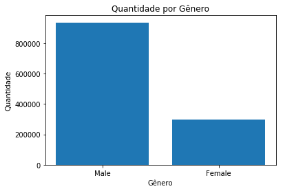

```python
# Verifique este gráfico!

gender_list = column_to_list(data_list, -2)
types = ["Male", "Female"]
quantity = count_gender(data_list)
y_pos = list(range(len(types)))
plt.bar(y_pos, quantity)
plt.ylabel('Quantidade')
plt.xlabel('Gênero')
plt.xticks(y_pos, types)
plt.title('Quantidade por Gênero')
plt.show(block=True)
```

**Tarefa 7:** *Crie um gráfico similar para user_types. Tenha certeza que a legenda está correta.*

```python
def count_user_types(data_list):
    """
    Função de para contar ocorrências de determinado tipo de usuario.
    Argumentos:
        data_list: Lista de dados.
    Retorna:
        Lista de com os valores acumulados para cada tipo de usuário.

    """
    customer = 0
    dependent = 0
    subscriber = 0
    user_type_column = 5

    for line in data_list:
        if line[user_type_column].lower() == 'customer':
            customer += 1
        elif line[user_type_column].lower() == 'dependent':
            dependent += 1
        elif line[user_type_column].lower() == 'subscriber':
            subscriber += 1

    return [customer, dependent, subscriber]
```

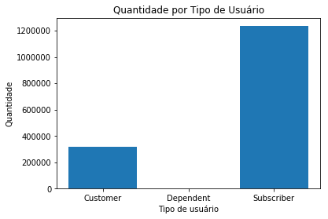

```python
user_list = column_to_list(data_list, 5)
types = ["Customer", "Dependent", "Subscriber"]
quantity = count_user_types(data_list)

# print("(debug) count_user_types:", quantity)

y_pos = list(range(len(types)))
plt.bar(y_pos, quantity)
plt.ylabel('Quantidade')
plt.xlabel('Tipo de usuário')
plt.xticks(y_pos, types)
plt.title('Quantidade por Tipo de Usuário')
plt.show(block=True)
```

**Tarefa 8:** *Por que a condição a seguir é Falsa?*

```python
male, female = count_gender(data_list)
print("Por que a condição a seguir é Falsa?")
print("male + female == len(data_list):", male + female == len(data_list))
```

```
Por que a condição a seguir é Falsa?
male + female == len(data_list): False
```

```python
# print("(debug) len(data_list):", len(data_list))
# print("(debug) male:", male, "and female:", female)
# print("(debug) len(data_list) - (male + female):", len(data_list) - (male + female))

def count_gender_with_blanks(data_list):
    """
    Função de para contar ocorrências de gênero (male/female) e desconhecido.
    Argumentos:
        data_list: Lista de dados.
    Retorna:
        Lista de com os valores acumulados para gênero (male/female) e desconhecido.

    """
    male = 0
    female = 0
    blanks = 0
    gender_column = 6

    for line in data_list:
        if line[gender_column].lower() == 'male':
            male += 1
        elif line[gender_column].lower() == 'female':
            female += 1
        else:
            blanks += 1

    return [male, female, blanks]

# print("(debug) count_gender_with_blanks:", count_gender_with_blanks(data_list))

answer = "Para analisar a pergunta eu utilizei o total da lista (1551505), total de male's (935854) e o total de female's (298784). Fiz a diferença do valor total da lista para soma de male's e female's. Esse valor equivale aos dados que não foram identificados nem como male e nem como female. Ao analisar novamente, reescrevi a função que faz a contagem e criei uma condição para que acumulasse também o valor dos dados que não foram identificados como male e female. Obtive 316867 que é exatamente o valor da diferença da lista para soma de male's e female's. Portanto, não existe apenas male e female, existem também campos que não estão preenchidos com esses dois valores e por esse motivo, a condição é falsa."

print("resposta:", answer)
```

```
resposta: Para analisar a pergunta eu utilizei o total da lista (1551505), total de male's (935854) e o total de female's (298784). Fiz a diferença do valor total da lista para soma de male's e female's. Esse valor equivale aos dados que não foram identificados nem como male e nem como female. Ao an…
```

**Tarefa 9:** *Ache a duração de viagem Mínima, Máxima, Média, e Mediana. Você não deve usar funções prontas para isso, como max() e min().*

```python
min_trip = 0.
max_trip = 0.
mean_trip = 0.
median_trip = 0.
trip_duration_list = column_to_list(data_list, 2)

def min_trip_list(trip_duration_list):
    """
    Função de para calcular duração de viagem mínima.
    Argumentos:
        trip_duration_list: Lista de dados da duração da viagem.
    Retorna:
        Float que representa valor mínimo calculado.

    """
    min_trip_duration_list = float(trip_duration_list[0])

    # print("(debug) min_trip_duration_list:", min_trip_duration_list)

    for line in trip_duration_list:
        if float(line) < min_trip_duration_list:
            min_trip_duration_list = float(line)
    return min_trip_duration_list


def max_trip_list(trip_duration_list):
    """
    Função de para calcular duração de viagem máxima.
    Argumentos:
        trip_duration_list: Lista de dados da duração da viagem.
    Retorna:
        Float que representa valor máximo calculado.

    """
    max_trip_duration_list = float(trip_duration_list[0])

    # print("(debug) max_trip_duration_list:", max_trip_duration_list)

    for line in trip_duration_list:
        if float(line) > max_trip_duration_list:
            max_trip_duration_list = float(line)
    return max_trip_duration_list


def mean_trip_list(trip_duration_list):
    """
    Função de para calcular duração média de viagem.
    Argumentos:
        trip_duration_list: Lista de dados da duração da viagem.
    Retorna:
        Float que representa valor médio calculado.

    """
    total_trip_duration_list = 0.

    for line in trip_duration_list:
        total_trip_duration_list += float(line)

    return total_trip_duration_list / len(trip_duration_list)


def median_trip_list(trip_duration_list):
    """
    Função de para calcular a mediana da duração de viagem.
    Argumentos:
        trip_duration_list: Lista de dados da duração da viagem.
    Retorna:
        Float que representa valor da mediana calculado.

    """
    trip_duration_list = sorted(float(line) for line in trip_duration_list)

    median_trip_duration_list = 0.
    middle = len(trip_duration_list) // 2

    # print("(debug) len(trip_duration_list):", len(trip_duration_list))
    # print("(debug) middle:", middle)

    if len(trip_duration_list) % 2 == 0:

        median_trip_duration_list = (float(trip_duration_list[middle]) + float(trip_duration_list[middle + 1])) / 2.0

    else:
        median_trip_duration_list = float(trip_duration_list[middle + 1])

    return median_trip_duration_list
```

```python
min_trip = min_trip_list(trip_duration_list)
max_trip = max_trip_list(trip_duration_list)
mean_trip = mean_trip_list(trip_duration_list)
median_trip = median_trip_list(trip_duration_list)

print("Min: ", min_trip, "Max: ", max_trip, "Mean: ", mean_trip, "Mediana: ", median_trip)
```

```
Min:  60.0 Max:  86338.0 Mean:  939.7777590146342 Mediana:  670.0
```

**Tarefa 10:** *Verifique quantos tipos de start_stations nós temos, usando set()*

```python
start_stations = set(column_to_list(data_list, 3))

print(len(start_stations))
print(start_stations)
```

```
582
{'Elmwood Ave & Austin St', 'Greenview Ave & Jarvis Ave', 'Ritchie Ct & Banks St', 'Phillips Ave & 79th St', 'Damen Ave & Charleston St', 'State St & 35th St', 'Kosciuszko Park', 'Ogden Ave & Congress Pkwy', 'Wells St & 19th St', 'Milwaukee Ave & Cuyler Ave', 'Lake Shore Dr & Belmont Ave', 'Kedzie A…
```

**Tarefa 11:** *Volte e tenha certeza que você documentou suas funções. Explique os parâmetros de entrada, a saída, e o que a função faz.*

```python
# def new_function(param1: int, param2: str) -> list:
#    """
#    Função de exemplo com anotações.
#    Argumentos:
#      param1: O primeiro parâmetro.
#      param2: O segundo parâmetro.
#      Retorna:
#       Uma lista de valores x.
#
#    """
```

**Tarefa 12:** *Crie uma função para contar tipos de usuários, sem definir os tipos para que nós possamos usar essa função com outra categoria de dados.*

```python
def count_items(column_list):
    """
    Função de para contar tipos de usuários, sem definir os tipos.
    Argumentos:
        column_list: Lista de dados.
    Retorna:
        Lista com tipos dos itens e contagem.

    """
    item_types = []
    count_items = []

    item_types = list(set(column_list))
    # print("(debug) item_types:", item_types)

    for item in item_types:
        count_items.append(column_list.count(item))

    return item_types, count_items
```

```python
column_list = column_to_list(data_list, -2)
types, counts = count_items(column_list)

print("Tipos:", types, "Counts:", counts)
```

```
Tipos: ['', 'Male', 'Female'] Counts: [316867, 935854, 298784]
```